# Topic: Web Scraping and Big Data (Analysis & Visualization)

### November 22, 2020

# Part 1: Scraping Craigslist

In this part, I extracted information on Philadelphia apartments from Craigslist search results. In fact, I used BeautifulSoup to extract the relevant information from the HTML text. Here's a sample URL that was returned after manually typing in a search to Craigslist: http://philadelphia.craigslist.org/search/apa?bedrooms=1&pets_cat=1&pets_dog=1&is_furnished=1. For the search parameters, I set `bedrooms=1`, which made sure the number of bedrooms was listed.

```python
# start with some packages I need
import pandas as pd
import matplotlib.pyplot as plt
import numpy as np

%matplotlib inline
```

[output not shown]

```python
import requests
```

```python
url_base = 'http://philadelphia.craigslist.org/search/apa'
params = {'bedrooms': 1}
rsp = requests.get(url_base, params=params)
```

```python
print(rsp.url)
```

```
https://philadelphia.craigslist.org/search/apa?bedrooms=1
```

## 1.1 Parse the HTML

- Use BeautifulSoup to parse the HTML response.
- Use browser's Web Inspector to identify the HTML element that holds the information on each apartment listing.
- Use BeautifulSoup to extract these elements from the HTML.

```python
from bs4 import BeautifulSoup
```

```python
html = BeautifulSoup(rsp.content, 'html.parser')
```

```python
apts = html.select('.result-row')
print(len(apts))
```

```
120
```

## 1.2 Find the relevant pieces of information

Next, I focused on the first element in the list of 120 apartments and printed out the HTML for this first element.

From this HTML, I identified the HTML elements that held:

- The apartment price
- The number of bedrooms and square footage (this will be in a single element)
- The apartment title
- The datetime string of the posting

For the first apartment, I printws out each of these pieces of information.

```python
this_appt = apts[0]
print(this_appt.prettify())
```

```
<li class="result-row" data-pid="7231991273">
 <a class="result-image gallery" data-ids="3:00C0C_cKjL7ClUmyC_1440I3,3:00808_eXycZ8AJC9d_1440I2,3:01616_k4Sfsym1Vij_1440I2,3:00E0E_klXFz5HjaQj_1440I3,3:00C0C_7idMyTFcAZV_1440I3,3:00J0J_9NRjatH3Ihg_1440I3,3:00v0v_83cKxUwDhTA_1440I2,3:00J0J_cbhNp4sZ5Kc_1440I3,3:00k0k_5Tk04Wi8ep9_0zW0Mf" href="https:/…
  <span class="result-price">
   $1,764
  </span>
 </a>
 <div class="result-info">
  <span class="icon icon-star" role="button">
   <span class="screen-reader-text">
    favorite this post
   </span>
  </span>
  <time class="result-date" datetime="2020-11-22 14:32" title="Sun 22 Nov 02:32:11 PM">
   Nov 22
  </time>
  <h3 class="result-heading">
   <a class="result-title hdrlnk" data-id="7231991273" href="https://philadelphia.craigslist.org/apa/d/west-chester-wireless-high-speed/7231991273.html" id="postid_7231991273">
    Wireless &amp; High Speed Internet Access, Air Conditioning, Garages
   </a>
  </h3>
  <span class="result-meta">
   <span class="result-price">
    $1,764
   </span>
   <span class="housing">
    2br -
                    926ft
    <sup>
     2
    </sup>
    -
   </span>
   <span class="result-tags">
    <span class="pictag">
     pic
    </span>
   </span>
   <span class="banish icon icon-trash" role="button">
    <span class="screen-reader-text">
     hide this posting
    </span>
   </span>
   <span aria-hidden="true" class="unbanish icon icon-trash red" role="button">
   </span>
   <a class="restore-link" href="#">
    <span class="restore-narrow-text">
     restore
    </span>
    <span class="restore-wide-text">
     restore this posting
    </span>
   </a>
  </span>
 </div>
</li>
```

```python
price = this_appt.select_one('.result-price').text
print(price)
```

```
$1,764
```

```python
housing = this_appt.select_one('.housing').text
print(housing)
```

```
                    2br -
                    926ft2 -
```

```python
title = this_appt.select_one(".result-title").text
print(title)
```

```
Wireless & High Speed Internet Access, Air Conditioning, Garages
```

```python
datetime = this_appt.select_one(".result-date")['datetime']
print(datetime)
```

```
2020-11-22 14:32
```

## 1.3 Functions to format the results

```python
import re
```

```python
def format_size_and_bedrooms(size_string):
    """
    Extract size and number of bedrooms from the raw
    text, using regular expressions
    """
    split = re.findall("\n(.*?) -", size_string)

    # both size and bedrooms are listed
    if len(split) == 2:
        n_brs = split[0].strip().replace('br', '')
        this_size = split[1].strip().replace('ft2', '')
    # only bedrooms is listed
    elif 'br' in split[0]:
        n_brs = split[0].strip().replace('br', '')
        this_size = np.nan
    # only size is listed
    elif 'ft2' in split[0]:
        # It's the size
        this_size = split[0].strip().replace('ft2', '')
        n_brs = np.nan

    # return floats
    return float(this_size), float(n_brs)
```

```python
def format_price(price_string):
    # Format the price string and return a float
    return float(price_string.strip("$"))
```

```python
def format_time(date_string):
    # Return a Datetime object from the datetime string
    return  pd.to_datetime(date_string)
```

## 1.4 Putting it all together

```python
from time import sleep
```

```python
results = []

# search in batches of 120 for 5 pages
max_pages = 5
results_per_page = 120
search_indices = np.arange(0, max_pages*results_per_page, results_per_page)
url = 'http://philadelphia.craigslist.org/search/apa'

# loop over each page of search results
for i, s in enumerate(search_indices):
    print('Processing page %s...' % (i+1) )

    # get the response
    resp = requests.get(url, params={'bedrooms': 1, 's': s})

    # get the list of all aparements
    # This is the same code from Part 1.1
    # It should be a list of 120 apartments
    apts = html.select('.result-row')
    print("number of apartments = ", len(apts))

    # loop over each apartment in the list
    page_results = []
    for apt in apts:

        # the bedrooms/size string
        sizes_brs = apt.select_one('.housing').text

        # the title string
        title = apt.select_one('.result-title').text

        # the price string
        price = apt.select_one('.result-price').text
        price = price.replace(',', '')

        # the time string
        dtime = apt.select_one('.result-date')['datetime']

        # format using functions from Part 1.3
        sizes, brs = format_size_and_bedrooms(sizes_brs)
        price = format_price(price)
        dtime = format_time(dtime)

        # save the result
        page_results.append([dtime, price, sizes, brs, title])


    # create a dataframe and save
    col_names = ['time', 'price', 'size', 'brs', 'title']
    df = pd.DataFrame(page_results, columns=col_names)
    results.append(df)

    print("sleeping for 30 seconds between calls")
    sleep(30)

# Finally, concatenate all the results
results = pd.concat(results, axis=0)
```

```
Processing page 1...
number of apartments =  120
sleeping for 30 seconds between calls
Processing page 2...
number of apartments =  120
sleeping for 30 seconds between calls
Processing page 3...
number of apartments =  120
sleeping for 30 seconds between calls
Processing page 4...
number of apartments =  120
sleeping for 30 seconds between calls
Processing page 5...
number of apartments =  120
sleeping for 30 seconds between calls
```

```python
# price = apt.select_one('.result-price').text
# print(price)
```

[output not shown]

```python
# price = price.replace(',', '')
# print(price)
```

[output not shown]

```python
# float(price.strip("$"))
```

[output not shown]

```python
results.head()
```

[output not shown]

## 1.5 Plotting the distribution of prices

### Plot 1. Histogram for apartment prices

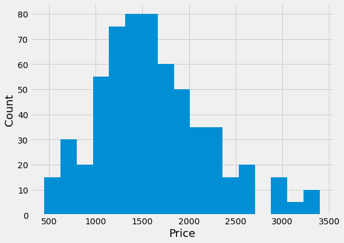

```python
with plt.style.context('fivethirtyeight'):

    # initialize the figure
    fig, ax = plt.subplots(figsize=(8, 6))

    # plot the histogram, using automatic bins
    ax.hist(results['price'], bins='auto')

    # label the axes
    ax.set_xlabel('Price', fontsize=18)
    ax.set_ylabel('Count', fontsize=18)
```

### Plot 2. Histogram for apartment prices per square foot (price / size)

The histogram of price per sq ft should be centered around ~1.5. [Source](https://arxiv.org/pdf/1605.05397.pdf)

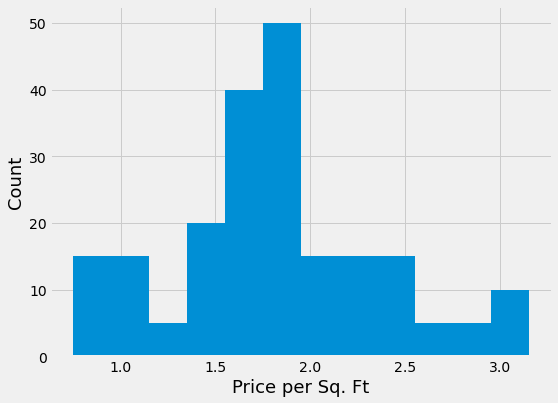

```python
with plt.style.context('fivethirtyeight'):

    # initialize the figure
    fig, ax = plt.subplots(figsize=(8, 6))

    # create the variable to indicate apartment prices per square foot
    results['unit_price'] = results['price']/ results['size']

    # select apartments with a valid size
    sel = results['size'] > 0

    # plot the histogram, using automatic bins
    ax.hist(results.loc[sel, 'unit_price'], bins='auto')

    # label the axes
    ax.set_xlabel('Price per Sq. Ft', fontsize=18)
    ax.set_ylabel('Count', fontsize=18)
```

## 1.6 Comparing prices for different sizes

In this section, I explored the relationship between price, size, and number of bedrooms. I Made an interactive scatter plot of price (x-axis) vs. size (y-axis), with the points colored by the number of bedrooms. With this sort of plot, we can quickly see the outlier apartments in terms of size and price.

```python
import altair as alt
alt.renderers.enable('notebook')
```

```
RendererRegistry.enable('notebook')
```

```python
alt.Chart(results).mark_point(size=60).encode(
    x=alt.X("price:Q"),
    y=alt.Y("size:Q"),
    color="brs:N",
    tooltip=["title", "price", "size", "brs"],
).interactive()
```

[output not shown]

# Part 2: Animated map of Philadelphia parking violations with Datashader

In this part, I loaded the data set of parking violations in Philadelphia from 2013 to present and made an animated map of the data using datashader. The data was animated by the hour in a day.

**Note: When using datashader, the loaded data's coordinates should be in Web Mercator (EPSG coe 3857)**

```python
conda install geopandas
```

[output not shown]

```python
import datashader as ds
import datashader.transfer_functions as tf
from datashader.colors import viridis
from datashader.utils import lnglat_to_meters as webm
import geopandas as gpd
```

## 2.1 Loaded data

```python
# load the city limits
city_limits = gpd.read_file("C:/Users/alber/OneDrive/Desktop/MUSA620-20200603/assignment-5-zizhaohe-master/City_Limits.geojson").to_crs(epsg=3857)
city_limits
```

|  | OBJECTID | Shape__Area | Shape__Length | geometry |
| --- | --- | --- | --- | --- |
| 0 | 1 | 3.970706e+09 | 394751.12047 | POLYGON ((-8350627.975 4886006.887, -8350960.2... |

```python
# load parking violations data
# downloaded from OpenDataPhilly
import glob

df = pd.concat(map(pd.read_csv, glob.glob('C:/Users/alber/OneDrive/Desktop/ParkingViolations/*.csv')))

# convert to web mercator x and y
df['x'], df['y'] = webm(df['lon'], df['lat'])

# add an hour column
df['issue_datetime'] = pd.to_datetime(df['issue_datetime'])
df['hour'] = df['issue_datetime'].dt.hour
```

```python
# df.head()
```

[output not shown]

## 2.2 Define functions

```python
def create_image(df, x_range, y_range, w=750, h=750, cmap=viridis):

    # create the canvas
    cvs = ds.Canvas(plot_width=w, plot_height=h, x_range=x_range, y_range=y_range)

    # plot dropoff positions, coutning number of passengers
    agg = cvs.points(df, 'x', 'y')

    # shade
    img = tf.shade(agg, cmap=cmap, how='eq_hist', min_alpha=150)

    # return an PIL image
    return tf.set_background(img, "black").to_pil()
```

```python
def convert_to_12hour(hr24):
    """
    Convert from 24 hr to 12 hr.
    """
    from datetime import datetime

    d = datetime.strptime(str(hr24), "%H")
    return d.strftime("%I %p")
```

```python
def plot_by_hour(fig, df_all_hours, hour, title):
    """
    Plot for a particular hour
    """
    # get the x and y range from the city limits
    # extent = [xmin, ymin, xmax, ymax]
    extent = city_limits.total_bounds
    x_range = extent[0], extent[2]
    y_range = extent[1], extent[3]

    # data for this hour
    df = df_all_hours.loc[df_all_hours['hour']==hour]

    # create the image for this hour
    img = create_image(df, x_range, y_range)

    # plot the image on a matplotlib axes
    plt.clf()
    ax = fig.gca()
    ax.imshow(img, extent=[*x_range, *y_range])
    ax.axis("off")

    # add city limits
    city_limits.plot(ax=ax, facecolor="none", edgecolor="white", linewidth=2)

    # add a text label for the hour
    t = convert_to_12hour(hour)
    ax.text(0.05, 0.9, t, color="white", fontsize=40, ha="left", transform=ax.transAxes)

    # add the title
    fig.text(0.72, 0.2, title, fontsize=35, color="white", ha="center")

    # format the axes
    ax.set_axis_off()
    ax.set_aspect("equal")
    fig.subplots_adjust(left=0, right=1, top=1, bottom=0)
    fig.tight_layout()

    # draw the figure and return the image
    fig.canvas.draw()
    image = np.frombuffer(fig.canvas.tostring_rgb(), dtype="uint8")
    image = image.reshape(fig.canvas.get_width_height()[::-1] + (3,))

    return image
```

## 2.3 Create the animate

```python
import imageio
```

```python
title = "Philadelphia\nParking Violations\n2013-present"
filename = 'parking_violations.gif'
```

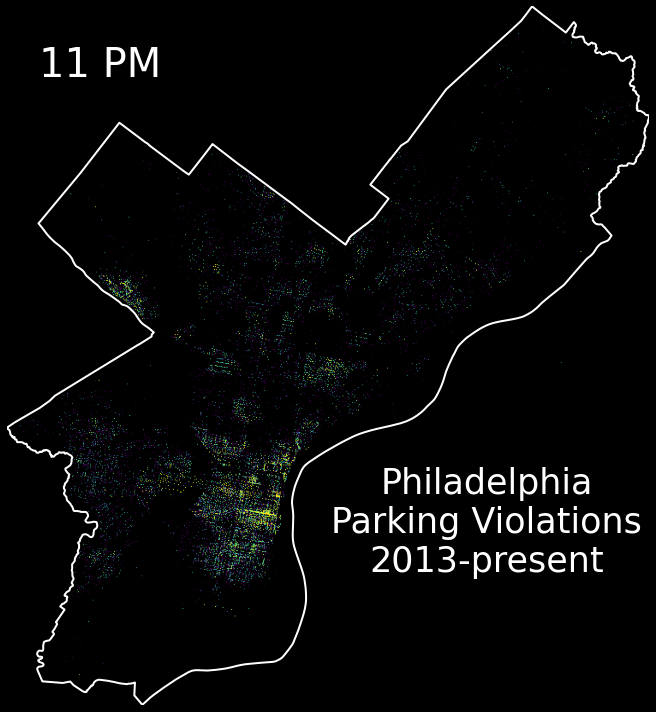

```python
# create a figure
fig, ax = plt.subplots(figsize=(10,10), facecolor='black')

# get the selection
hours = list(range(24))
fps = 1

# make the images for each hour
images = []
for hour in hours:
    image = plot_by_hour(fig, df, hour, title)
    images.append(image)

# combine the images into a GIF
imageio.mimsave(filename, images, fps=fps);
```

**Summary: From observing the GIF, we can easily find that from 2013 to present, in a day, parking violations mostly happened between 7am and 1pm, especially in the Center City area. Thus, in order to effectively reduce parking violations in Philly, I believe new parking policies should focus on supervising or managing in this time period without doubt.**